# IMT 573: Lab 6 - Simple Regression

Madhusmita Oke

# Setup

Do whatever setup you do here, such as loading libraries

```r
# Load standard libraries
library("tidyverse")
```

# 1 States Data

## 1.1 Matrix to data frame

```r
df_us_states <- data.frame(state.x77)
dim(df_us_states)
```

```
## [1] 50  8
```

```r
names(df_us_states)
```

```
## [1] "Population" "Income"     "Illiteracy" "Life.Exp"   "Murder"
## [6] "HS.Grad"    "Frost"      "Area"
```

```r
head(df_us_states, 4)
```

```
##          Population Income Illiteracy Life.Exp Murder HS.Grad Frost   Area
## Alabama        3615   3624        2.1    69.05   15.1    41.3    20  50708
## Alaska          365   6315        1.5    69.31   11.3    66.7   152 566432
## Arizona        2212   4530        1.8    70.55    7.8    58.1    15 113417
## Arkansas       2110   3378        1.9    70.66   10.1    39.9    65  51945
```

# 2 Analyse Data

## 2.1 What do you expect to see for relation between income and HS.Grad ?

I think the income should tend to increase for folks for states having more percentage of HS.Grad education.

## 2.2 Plot the graph Income(Vertical) vs HS.Grad , add regression line on the plot

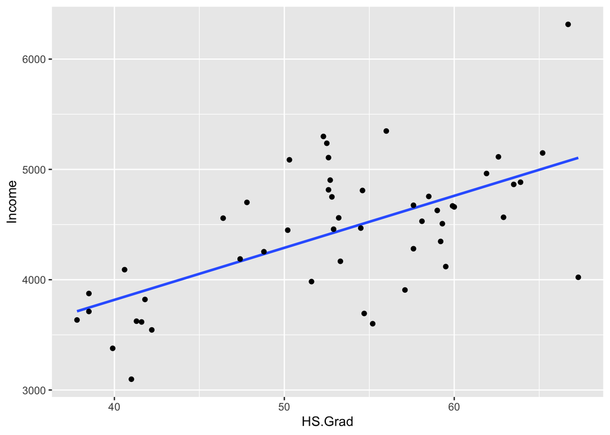

```r
plot1 <- ggplot(df_us_states, aes(HS.Grad, Income))+geom_smooth(method="lm", se=FALSE) + geom_point()

plot1
```

## 2.3 Upward sloping or downward sloping? Do you see dots treding up or down the line?

The Regression line is upward sloping. We can see the dots are trending up and down in the similar fashion as the line.

## 2.4 Run the Regression

```r
m <- lm(Income ~ HS.Grad,data= df_us_states )
summary(m)
```

```
##
## Call:
## lm(formula = Income ~ HS.Grad, data = df_us_states)
##
## Residuals:
##      Min       1Q   Median       3Q      Max
## -1083.13  -277.41   -34.15   241.46  1238.17
##
## Coefficients:
##             Estimate Std. Error t value Pr(>|t|)
## (Intercept) 1931.105    462.739   4.173 0.000125 ***
## HS.Grad       47.162      8.616   5.474 1.58e-06 ***
## ---
## Signif. codes:  0 '***' 0.001 '**' 0.01 '*' 0.05 '.' 0.1 ' ' 1
##
## Residual standard error: 487.1 on 48 degrees of freedom
## Multiple R-squared:  0.3843, Adjusted R-squared:  0.3715
## F-statistic: 29.96 on 1 and 48 DF,  p-value: 1.579e-06
```

## 2.5 Interpret the output of Regression

The beta0 is 1931.105 and beta1 47.162. Beta1 is an indicator that with 1 unit increase(here 1 unit is 1% increase) in HS.Grad (X) variable there is 47.162 units increase in Income (Y). Beta0 value indicates what is the Income(Y) when HS.Grad(X) is 0 units (here 0%)

## 2.6 p-value & its significance

The p-value for the data we measured is 1.58 * 10^-6 which is very small thus we can reject the null hypothesis which is - there is no relation between Income and High school-Grad education percentage. Thus we can say that there is possible positive association between Income and HS.Grad

## 2.7 What do these numbers tell about association of Education and Income?

Since the p-value is significantly smaller we can say that Education and Income are likely to be associated

# 3 Analyze murder and life expectancy

Analyze murder and life expectancy

## 3.1 What will the relationship look like?

Logically, the life expectancy would decrease with increase in murder percentage!

## 3.2 Plot graph Life Exp vs Murder

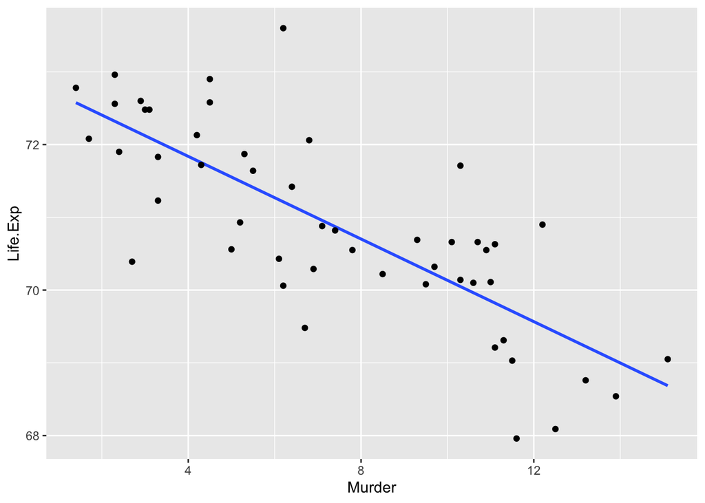

```r
plot2 <- ggplot(df_us_states, aes(Murder, Life.Exp))+geom_smooth(method="lm", se=FALSE) + geom_point()

plot2
```

The plot confirms my obvious expectation. It is a downward growing graph

## 3.3 Regression output

```r
m2 <- lm(Life.Exp ~ Murder,data= df_us_states )
summary(m2)
```

```
##
## Call:
## lm(formula = Life.Exp ~ Murder, data = df_us_states)
##
## Residuals:
##      Min       1Q   Median       3Q      Max
## -1.81690 -0.48139  0.09591  0.39769  2.38691
##
## Coefficients:
##             Estimate Std. Error t value Pr(>|t|)
## (Intercept) 72.97356    0.26997  270.30  < 2e-16 ***
## Murder      -0.28395    0.03279   -8.66 2.26e-11 ***
## ---
## Signif. codes:  0 '***' 0.001 '**' 0.01 '*' 0.05 '.' 0.1 ' ' 1
##
## Residual standard error: 0.8473 on 48 degrees of freedom
## Multiple R-squared:  0.6097, Adjusted R-squared:  0.6016
## F-statistic: 74.99 on 1 and 48 DF,  p-value: 2.26e-11
```

## 3.4 Interpret co-efficients b0 and b1 (beta0 and beta1)

Here b0 is 72.97356 and b1 is -0.28395. b0 indicates that when Murder is 0, Life Exp is 72.97356. b1 is negative, it indicates that with increase in 1 unit murder parameter, life exp decreases by ~0.284.

## 3.5 t-value and interpretation?

Negative t-value would indicate that X variable affects dependent variable Y in opposite way.For the data above, t-value is negative - which indicates that with increase in murder, life expectancy decreases.

## 3.6 What do these number tell about society / crime/ life expectancy!

We can say that with decrease in murder /crime rates the life expectancy is likely to increase. Hence it is important to better safety of our society in order to have higher / healthier life expectancy!